# RECONFERENCIAEXPEDIÇÃO

- > **RECONFERÊNCIA**
- > Clicar em “Busca Tarefa” para Reconferência.

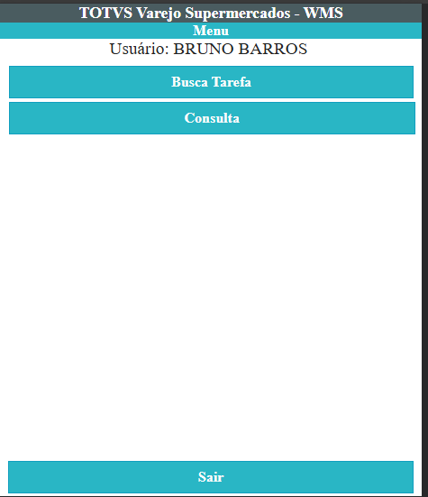

- > Na tela abaixo, vamos bipar a etiqueta, caso algum erro ocorra, vamos digitar manualmente o código da etiqueta localizado abaixo do código de barras.

[figure not shown]

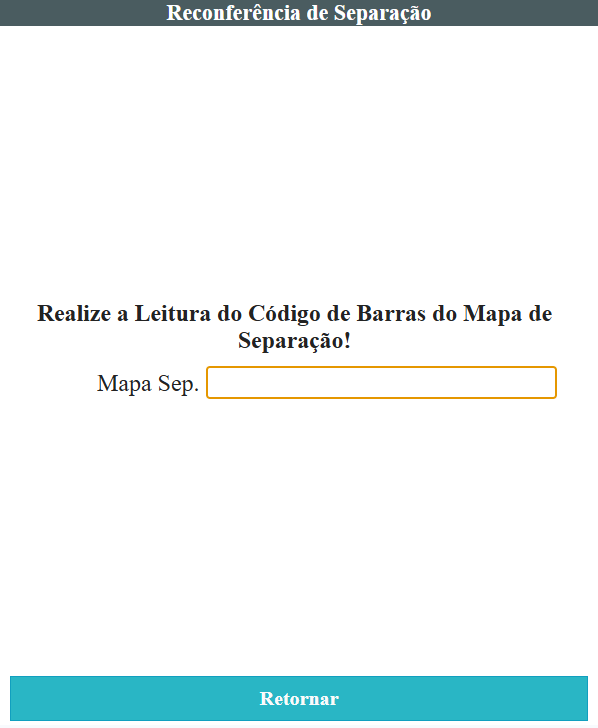

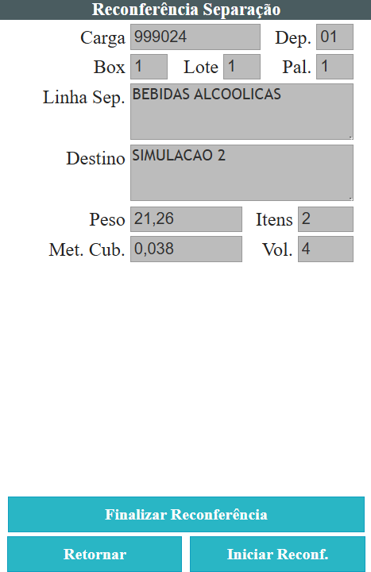

- > Caso apareça a tela abaixo, é necessário bipar novamente a etiqueta, ou inserir manualmente o código da etiqueta.

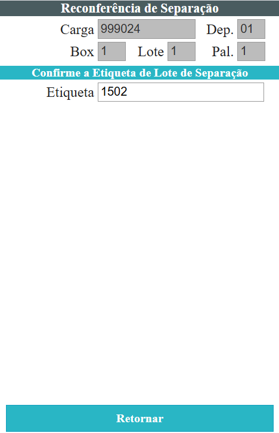

- Existem duas maneiras de conferir os produtos, conforme explicações abaixo:

[figure not shown]

[figure not shown]

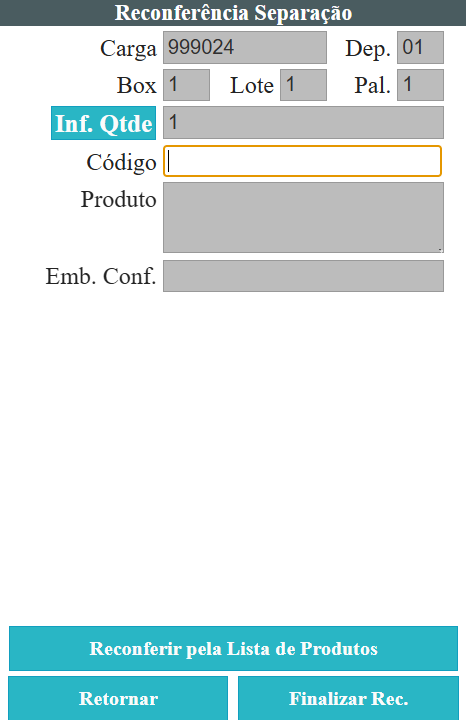

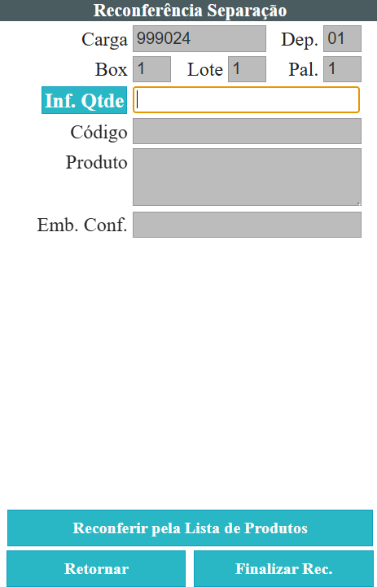

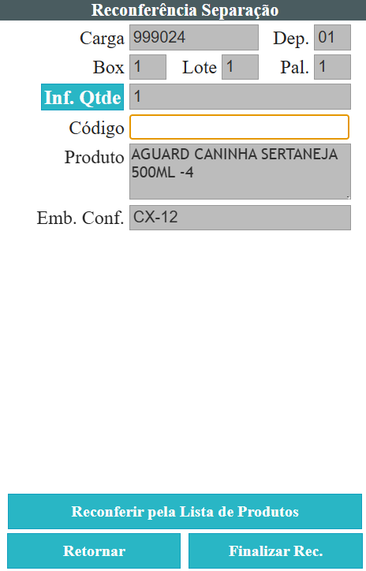

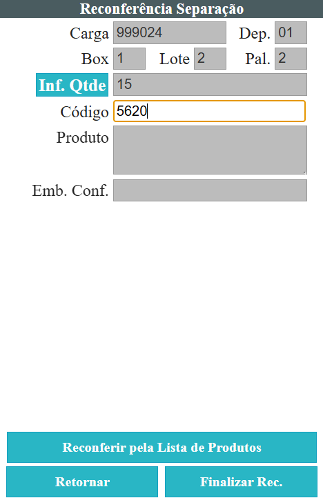

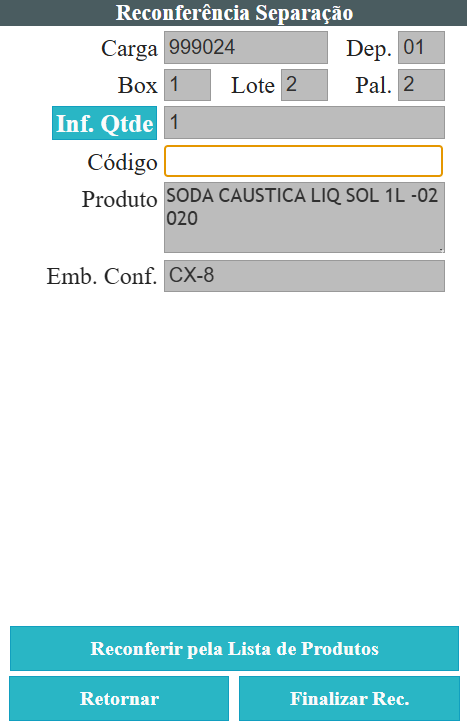

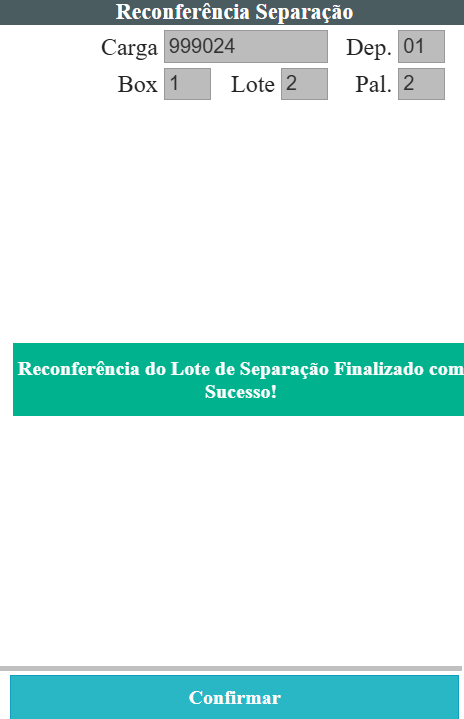

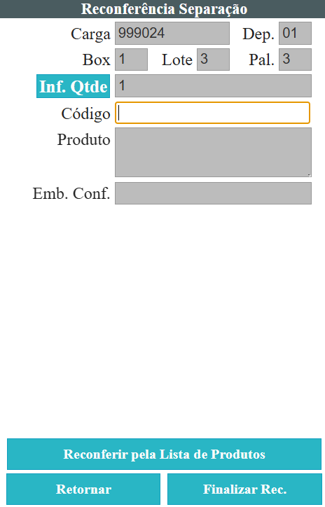

- > Após clica em Reconferir pela lista de Produtos aparecerá a tela na qual você pode apenas consultar ou conferir os itens do lote clicando no item que deseja conferir.

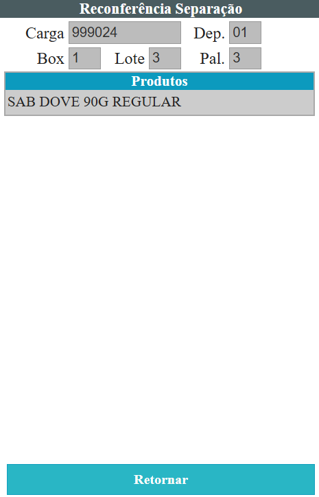

- > Clicando no item que deseja, aparecerá uma tela na qual mostrará o código do produto, descrição do produto na qual você deve informar a quantidade e clicar em Confirma.

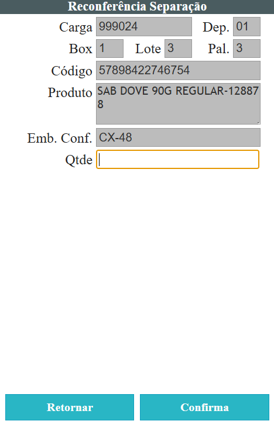

- > Após, clique em Finalizar Reconferência.

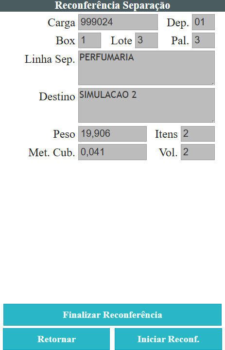

- > Havendo pendência/divergência na carga, aparecerá a mensagem “Reconferência com divergência”. Caso queira averiguar ou eliminar a divergência bipando no produto trago pela pendência ou encontrado na carga por erro da conferência será possível efetuar a correção clicando em Listar Divergências.

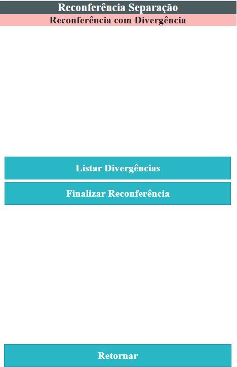

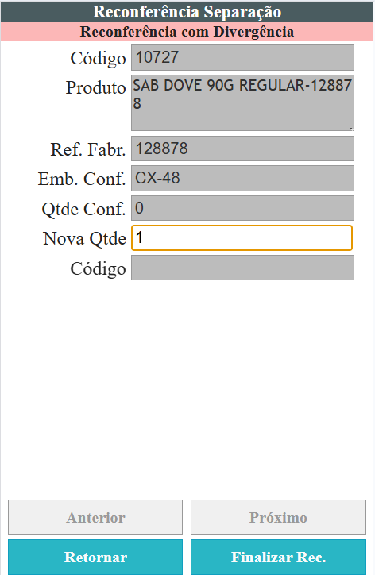

- > Caso queira finalizar a reconferência com divergência, sistema irá informar que foi gerado atividade de busca pendência, após clicar em confirmar.

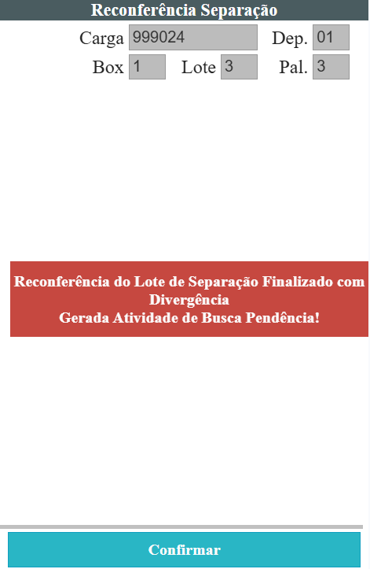

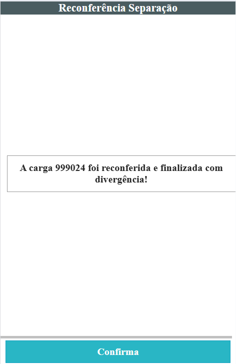